# Análisis exploratorio de la encuesta inicial

### Sexta pregunta

*¿Qué relación existe entre la carrera de cada uno de los estudiantes, su PAPA y su puntaje en el ICFES?*

Aunque no tenemos ninguna seguridad, vamos a plantear inicialmente que los estudiantes de la carrera de ingeniería de sistemas tendrán en general un PAPA más alto, al igual que un puntaje en sus pruebas Saber también más alto. El resto de carreras no se tienen en cuenta para analizar por la poca cantidad de estudiantes pertenecientes a dichas carreras.

#### Resumen numérico: Estudiantes de Ingeniería de Sistemas e Informática

```
##                            Intervalos del PAPA
## Intervalos Puntaje SABER 11 [3,3.5] (3.5,4] (4,4.5] (4.5,5]
##                   [0,250]         0       0       0       0
##                   (250,300]       0       2       1       0
##                   (300,350]       1       3       3       1
##                   (350,400]       1       3       5       2
##                   (400,500]       0       1       1       0
```

##### Resumen del PAPA de los estudiantes de ingeniería de sistemas:

```
##    Min. 1st Qu.  Median    Mean 3rd Qu.    Max.    NA's
##   3.400   3.800   4.100   4.096   4.300   4.700       2
```

##### Resumen del Puntaje en las pruebas SABER 11 para los estudiantes de ingeniería de sistemas:

```
##    Min. 1st Qu.  Median    Mean 3rd Qu.    Max.    NA's
##   270.0   325.0   356.5   350.0   372.0   430.0       2
```

#### Resumen numérico: Estudiantes de Estadística

```
##                            Intervalos del PAPA
## Intervalos Puntaje SABER 11 [3,3.5] (3.5,4] (4,4.5] (4.5,5]
##                   [0,250]         1       1       1       0
##                   (250,300]       2       5       5       1
##                   (300,350]       3       6      12       1
##                   (350,400]       0       3       3       0
##                   (400,500]       0       1       0       1
```

##### Resumen del PAPA de los estudiantes de estadística:

```
##    Min. 1st Qu.  Median    Mean 3rd Qu.    Max.    NA's
##   3.000   3.825   4.100   4.033   4.300   4.700       8
```

##### Resumen del Puntaje en las pruebas SABER 11 para los estudiantes de estadística del curso:

```
##    Min. 1st Qu.  Median    Mean 3rd Qu.    Max.    NA's
##   157.0   298.2   319.0   319.7   345.2   500.0       8
```

#### Gráficas exploratorias

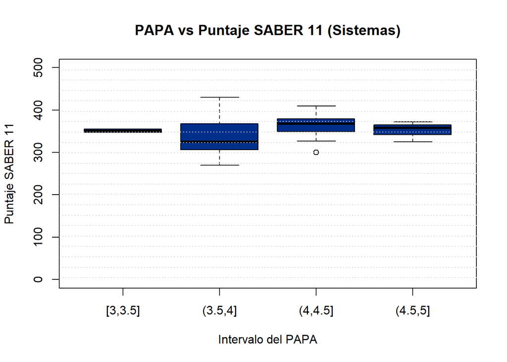

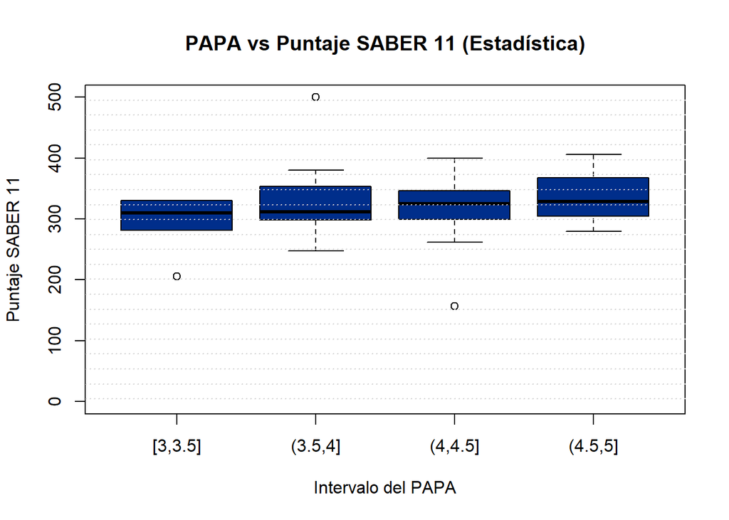

#### Análisis

En los resúmenes numéricos se observa que en promedio no se presentan diferencias significativas entre el PAPA de los estudiantes de ingeniería de sistemas y el PAPA de los de estadística. Además, por el lado de las pruebas SABER 11, se ve que los estudiantes de ingeniería de sistemas tuvieron en promedio mejores puntajes que los de estadística. Sin embargo, el mayor puntaje en las pruebas SABER 11 corresponde a un estudiante de estadística, aunque este es un caso atípico y por eso no es representativo para los estudiantes de estadística.

Al pasar a analizar las gráficas, resulta interesante ver cierta tendencia en los estudiantes de estadística, tendencia que consiste en que, a mayor PAPA, mayor puntaje obtenido en las pruebas SABER 11; sin embargo, esta tendencia no se logra apreciar con los estudiantes de ingeniería de sistemas, por lo que no se puede asegurar que el puntaje en las pruebas SABER 11 esté relaciona con el PAPA. En las gráficas también se puede verificar lo que se observó en los resúmenes numéricos: que los estudiantes de sistemas tuvieron mejor puntaje en sus pruebas SABER 11.

### Séptima pregunta

*¿Tienen mejor PAPA aquellos estudiantes que son de estrato socioeconómico alto y que residen en el Área Metropolitana del Valle de Aburrá en comparación con aquellos que son de estrato socioeconómico bajo y habitan por fuera de esta?*

Se podría esperar que una persona que vive en el Área Metropolitana del Valle de Aburrá y que tenga buenos ingresos económicos tiene más posibilidades de mejorar su promedio académico, ya que se encuentra más cerca de la Universidad y tiene más posibilidades de asesorías privadas o cursos para mejorar su promedio, mientras que alguien fuera del Valle de Aburrá con pocos ingresos le es mucho más difícil adquirir estos privilegios.

#### Resumen numérico personas que si residen en el Area Metropolitana del Valle de Aburra

Se realiza una tabla donde se evidencia el numero de personas que están residiendo en el área metropolitana y que pertenecen a los estratos 1, 2, 3, 4, y 5.

```
##               Intervalos del PAPA
## Estrato        [3,3.5] (3.5,4] (4,4.5] (4.5,5]
##   1                  0       0       0       0
##   2                  3       6       7       3
##   3                  5      13      12       2
##   4                  0       2       4       0
##   5                  0       0       1       0
##   No se conoce       0       0       1       0
```

##### **Resumen numérico de las personas que viven en el Valle de Aburrá y son de estrato uno**

En este caso no es necesario realizar un resumen numérico, ya que como se observa en la tabla anterior, no hay personas que viven dentro del Valle de Aburrá y que su residencia esté catalogada como de estrato uno.

##### Resumen numérico de las personas que viven en el Valle de Aburrá y son de estrato dos

```
##    Min. 1st Qu.  Median    Mean 3rd Qu.    Max.
##   3.000   3.750   4.100   4.021   4.300   4.700
```

##### Resumen numérico de las personas que viven en el Valle de Aburrá y son de estrato tres

```
##    Min. 1st Qu.  Median    Mean 3rd Qu.    Max.    NA's
##   3.000   3.800   4.000   4.006   4.300   4.600       4
```

##### Resumen numérico de las personas que viven en el Valle de Aburrá y son de estrato cuatro

```
##    Min. 1st Qu.  Median    Mean 3rd Qu.    Max.
##   4.000   4.025   4.100   4.167   4.250   4.500
```

##### Resumen numérico de las personas que viven en el Valle de Aburrá y son de estrato cinco

```
##    Min. 1st Qu.  Median    Mean 3rd Qu.    Max.
##     4.3     4.3     4.3     4.3     4.3     4.3
```

##### Resumen numérico personas que no residen en el Área Metropolitana del Valle de Aburra

```
##               Intervalos del PAPA
## Estrato        [3,3.5] (3.5,4] (4,4.5] (4.5,5]
##   1                  1       2       2       0
##   2                  0       2       2       1
##   3                  1       2       5       1
##   4                  0       0       0       0
##   5                  0       0       0       0
##   No se conoce       0       0       0       0
```

##### Resumen numérico de las personas que no viven en el Valle de Aburrá y son de estrato uno

```
##    Min. 1st Qu.  Median    Mean 3rd Qu.    Max.    NA's
##     3.2     3.7     3.7     3.8     4.2     4.2       3
```

##### Resumen numérico de las personas que no viven en el Valle de Aburrá y son de estrato dos

```
##    Min. 1st Qu.  Median    Mean 3rd Qu.    Max.    NA's
##    3.80    3.90    4.30    4.24    4.50    4.70       2
```

##### Resumen numérico de las personas que no viven en el Valle de Aburrá y son de estrato tres

```
##    Min. 1st Qu.  Median    Mean 3rd Qu.    Max.
##   3.400   3.900   4.200   4.111   4.500   4.600
```

##### **Resumen numérico de las personas que no viven en el Valle de Aburrá y son de estrato cuatro**

En este caso no es necesario realizar un resumen numérico, ya que como se observa en la tabla anterior, no hay personas que viven por fuera del Valle de Aburrá y que su residencia esté catalogada como de estrato cuatro

##### **Resumen numérico de las personas que no viven en el Valle de Aburrá y son de estrato cinco**

En este caso no es necesario realizar un resumen numérico, ya que como se observa en la tabla anterior, no hay personas que viven por fuera del Valle de Aburrá y que su residencia esté catalogada como de estrato cinco.

#### Gráficas exploratorias

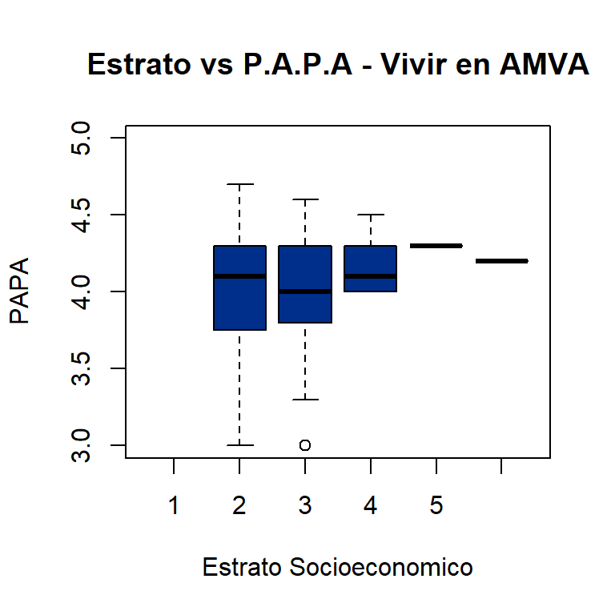

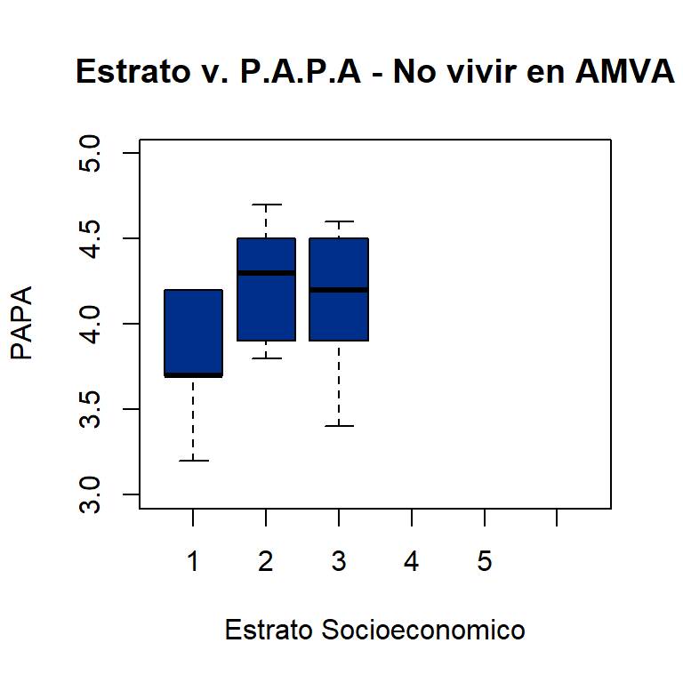

#### Análisis

Los datos de las variables PAPA, estrato y residencia o no en AMVA fueron debidamente analizados y filtrados para poder realizar los anteriores diagramas de cajas y bigotes. El primer diagrama nos responde a la pregunta siete planteada al comienzo, la cual nos cuestionaba si pertenecer a un estrato alto y residir en el AMVA tenía relación directa con tener un PAPA alto, para lo cual no hay evidencia suficiente para decir que estas personas de estrato alto (cuatro y cinco) y residen en el AMVA tienen mejor PAPA que los de menor estrato, pues como vemos, la caja del estrato cinco corta al las otras y además, se debe tener en cuenta que los datos de personas de estrato cinco que viven en el AMVA son muy pocos comparados con sus pares de menor estrato, por lo cual no se puede realizar un análisis totalmente adecuado dada la insuficiencia de información en este caso.

Planteando esta pregunta en otro contexto, que sería pertenecer a estrato bajo (estratos uno y dos) y no residir en el AMVA, se ve que no hay diferencias en promedio con sus pares de estrato medio-bajo (estrato alto); pero aquí vale la pena destacar que no es posible realizar una comparación con los estratos altos por fuera del AMVA, ya que no se muestrearon datos para este caso. Sin embargo, se puede resaltar que la mediana se aproxima al primer cuartil para el estrato uno.

Finalmente, revisando las cajas que corresponden a los estratos altos (cuatro y cinco) de los estudiantes de EDAED que viven en el AMVA, con los de estratos bajos (uno, dos y tres) que no, se observa que las cajas se traslapan entre sí y, en consecuencia, no habría diferencias en promedio en el PAPA de los estudiantes que viven en el AMVA y son de estrato alto con los estudiantes de EDAED que no residen en tal subregión y que son de estrato bajo. Solo se presenta una excepción en el caso del estrato cinco en AMVA con el estrato uno por fuera del AMVA, pero nuevamente, se considera que los estudiantes que viven en el AMVA y son de estrato cinco no son los suficientes como para poder hacer una comparación adecuada.

Por lo demás, se puede mencionar que en la mayoría de los casos hay una dispersión considerable de los datos considerando el tamaño de sus respectivas cajas, salvo en el caso de los estudiantes de estrato cuatro y cinco del AMVA.

### Octava pregunta

*¿Tienen el R instalado las personas de estrato socioeconómico más alto y con más recursos tecnológicos propios?*

Se podría esperar que, un estudiante con mayores recursos económicos y tecnológicos tenga el r instalado, mientras que, una persona que no cuenta con las mismas posibilidades de una persona de estrato alto, sería más propensa a no tener el r instalado.

#### Resumen númerico personas con recursos tecnologícos

```
##               Número de recursos propios
## Estrato         0  1  2  3  4  5
##   1             2  2  4  0  0  0
##   2             2  1 13  8  2  0
##   3             0  2 14 19  6  4
##   4             0  0  1  1  2  2
##   5             0  0  0  1  0  0
##   No se conoce  0  0  1  0  0  0
```

#### Resumen numérico para instalación de R

A continuación se presenta una tabla donde se observa la cantidad de personas que han instalado R o no por estrato.

```
##               R instalado
## Estrato        No Si
##   1             1  7
##   2             3 23
##   3             3 42
##   4             0  6
##   5             0  1
##   No se conoce  0  1
```

##### Resumen numérico para la cantidad de recursos de los estratos 4 y 5

```
##    Min. 1st Qu.  Median    Mean 3rd Qu.    Max.
##   2.000   3.000   4.000   3.714   4.500   5.000
```

##### Resumen numérico para la cantidad de recursos de los estratos 1, 2 y 3

[output not shown]

#### Gráfica exploratoria

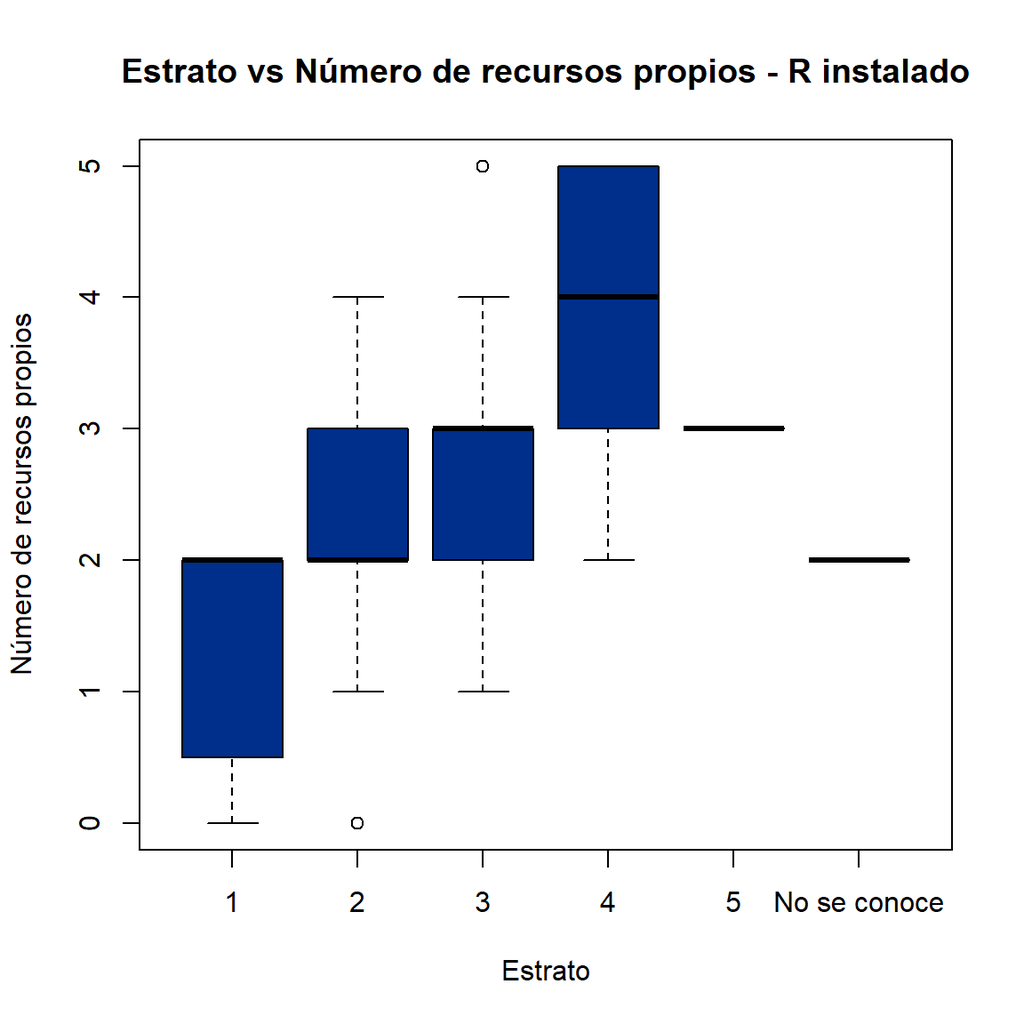

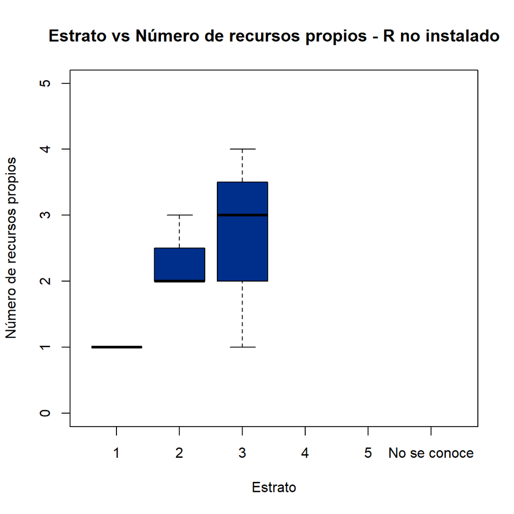

### Novena pregunta

*Se puede plantear alguna diferencia entre el PAPA y el número de conspiraciones falsas que se creen verdaderas en función del género del estudiante?*

A partir de lo visto en la segunda pregunta, se puede plantear que existe una ligera diferencia en el PAPA de los estudiantes que creen en un mayor número de conspiraciones y que estas se van a conservar para cada uno de los géneros estudiantes, si bien al comparar los diferentes géneros entre sí, no se podrán establacer diferencias entre ellos, lo que quiere decir que el género no se correlaciona con el PAPA y el número de creencias falsas que creen los estudiantes.

#### Resumen numérico: personas del género femenino

La siguiente es una tabla que da cuenta del número de conspiraciones que están documentadas como falsas pero que son asumidas como verdaderas por parte de las mujeres del curso de EDAED:

```
##                 Intervalos del PAPA
## # Conspiraciones [3,3.5] (3.5,4] (4,4.5] (4.5,5]
##                0       0       0       1       1
##                1       0       4       3       1
##                2       0       3       3       1
##                3       0       0       0       0
##                4       0       0       0       0
##                5       0       0       0       0
```

Y se pueden obtener los siguientes resúmenes numéricos:

##### Resumen numérico del PAPA para las personas del género femenino que no creen en ninguna conspiración falsa

```
##    Min. 1st Qu.  Median    Mean 3rd Qu.    Max.    NA's
##   4.200   4.325   4.450   4.450   4.575   4.700       1
```

##### Resumen numérico del PAPA para las personas del género femenino que en una conspiración falsa

```
##    Min. 1st Qu.  Median    Mean 3rd Qu.    Max.    NA's
##   3.600   3.800   4.100   4.112   4.350   4.700       1
```

##### Resumen numérico del PAPA para las personas del género femenino que en dos conspiraciones falsa

```
##    Min. 1st Qu.  Median    Mean 3rd Qu.    Max.
##   3.600   4.000   4.200   4.186   4.400   4.700
```

#### Resumen numérico: personas del género masculino

La siguiente es una tabla que da cuenta del número de conspiraciones que están documentadas como falsas pero que son asumidas como verdaderas por parte de las personas que se autoperciben como parte del género masculino del curso de EDAED:

```
##                 Intervalos del PAPA
## # Conspiraciones [3,3.5] (3.5,4] (4,4.5] (4.5,5]
##                0       7       8      11       4
##                1       0       6      11       0
##                2       2       3       3       0
##                3       0       0       2       0
##                4       0       2       0       0
##                5       1       0       0       0
```

Y se pueden obtener los siguientes resúmenes numéricos:

##### Resumen numérico del PAPA para las personas del género masculino que no creen en ninguna conspiración falsa

```
##    Min. 1st Qu.  Median    Mean 3rd Qu.    Max.    NA's
##   3.000   3.725   4.050   3.990   4.300   4.600       2
```

##### Resumen numérico del PAPA para las personas del género masculino que en una conspiración falsa

```
##    Min. 1st Qu.  Median    Mean 3rd Qu.    Max.    NA's
##   3.700   4.000   4.200   4.171   4.400   4.500       2
```

##### Resumen numérico del PAPA para las personas del género masculino que en dos conspiraciones falsa

```
##    Min. 1st Qu.  Median    Mean 3rd Qu.    Max.    NA's
##    3.00    3.65    3.85    3.80    4.10    4.30       2
```

##### Resumen numérico del PAPA para las personas del género masculino que en tres conspiraciones falsa

```
##    Min. 1st Qu.  Median    Mean 3rd Qu.    Max.
##   4.100   4.125   4.150   4.150   4.175   4.200
```

##### Resumen numérico del PAPA para las personas del género masculino que en cuatro conspiraciones falsa

```
##    Min. 1st Qu.  Median    Mean 3rd Qu.    Max.
##   3.700   3.775   3.850   3.850   3.925   4.000
```

##### Resumen numérico del PAPA para las personas del género masculino que en cinco conspiraciones falsa

```
##    Min. 1st Qu.  Median    Mean 3rd Qu.    Max.
##     3.2     3.2     3.2     3.2     3.2     3.2
```

#### Resumen numérico: personas no binarias

Ahora se van a obtener análisis numéricos para las personas no binarias del curso de EDAED, es decir, aquellas que no se perciben como parte del género femenino o masculino, que en realidad se va a simplificar bastante en el sentido que como se vio en el análisis univariado, solo existe una persona dentro de esta categoría, que igual se puede corroborar en la siguiente tabla donde solo hay un valor diferente de cero, siendo este exactamente igual uno.

```
##                 Intervalos del PAPA
## # Conspiraciones [3,3.5] (3.5,4] (4,4.5] (4.5,5]
##                0       0       1       0       0
##                1       0       0       0       0
##                2       0       0       0       0
##                3       0       0       0       0
##                4       0       0       0       0
##                5       0       0       0       0
```

Y en este caso, no tiene sentido presentar un resumen numérico para esta submuestra con una sola observación, pues el resultado es bastante obvio en el sentido que toda la información que se puede obtener es la dada por esta persona. Así, se establece que la persona no binaria del curso no cree en ninguna conspiración falsa, o dicho de otra manera, el 100 % de los estudiantes no binarios del curso de EDAED no creen en ninguna conspiración documentada como falsa.

#### Gráfica exploratoria

Para este ejercicio se debe considerar que para el caso de la persona no binaria, al no ser una submuestra de un tamaño lo suficientemente grande como para poder contrastarlo efectivamente con las personas del género femenino y masculino.

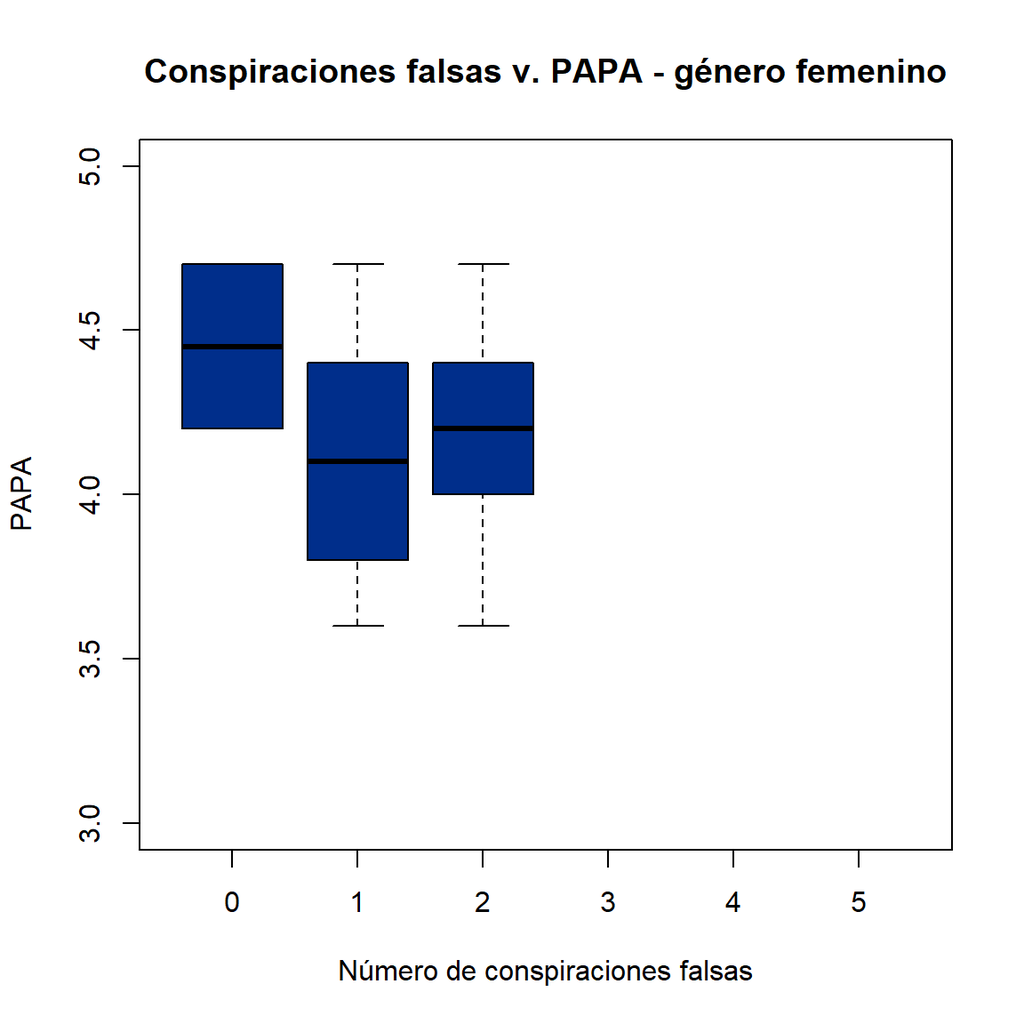

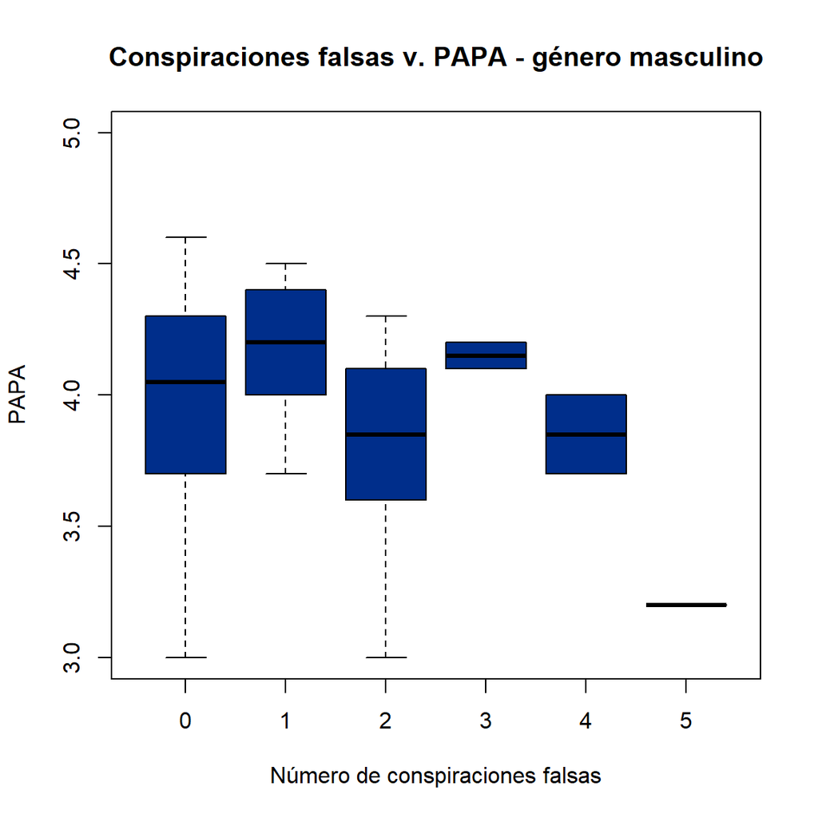

#### Análisis

A partir de los boxplots anteriores, se puede observar que, en términos generales, no hay diferencias en promedio en el número de conspiraciones falsas (y documentadas como tal) pero consideradas verdaderas de acuerdo con el PAPA entre géneros y en cada uno de ellos, salvo en el caso de los estudiantes de género masculino que creen en cinco conspiraciones dadas como falsas, que en promedio tienen menor PAPA que todos los demás estudiantes del curso de EDAED independientemente de su género, pero se debe ser cuidadosos respecto a estos en tanto la submuestra es personas de género masculino que creen en cinco conspiraciones falsas es muy pequeña en comparación con el resto, lo cual da indicios de que podría resultar en un análisis sesgado.

Por otro parte, es curioso que la mediana del PAPA de las personas del curso de EDAED de género femenino es ligeramente mayor que la de los estudiantes de género masculino que solo creen en cero, dos y cuatro conspiraciones, además que hay una menor tendencia en las personas de género femenino en asumir tales conspiraciones como ciertas, lo cual se evidencia en una cantidad nula de personas de este género que creen en cuatro o cinco conspiraciones, lo cual no es el caso para el otro género.

Finalmente, se debe hacer mención de que para efectos de este análisis, no fue considerada la persona no binario teniendo presente que su muestra era de una única persona, lo cual podría conducir a análisis sesgados.

### Décima pregunta

*¿Hay diferencias entre el tiempo que se pudieron haber tomado los estudiantes para resolver las preguntas de álgebra considerando su género?*

En este caso, se va a considerar que no se puede establecer diferencias entre hombres y mujeres respecto a la cantidad de preguntas que respondieron correctamente de álgebra en la tercera parte de la encuesta en conformidad con su género.

#### Resumen numérico: personas del género femenino

Inicialmente se presenta una tabla que resumen la información asociada a este caso. Se puede observar que la variable ‘tiempo empleado’ está siendo agrupada en grupos de cinco minutos cada uno con el objetivo de presentar de manera suscinta tal table, pues esta variable es continua.

```
##                       Intervalos de tiempo empleado [min]
## # Respuestas correctas [0,5] (5,10] (10,15] (15,20] (20,25] (25,30]
##                      1     0      0       2       5       5       1
##                      2     0      0       2       1       0       0
##                      3     0      0       1       1       2       0
```

A partir de esta tabla, se puede presentar un resumen numérico separado para cada caso de número de respuestas correctas.

##### Resumen numérico del tiempo empleado para las mujeres con una respuesta correcta

```
##    Min. 1st Qu.  Median    Mean 3rd Qu.    Max.
##   10.83   16.95   19.98   19.08   20.60   28.93
```

##### Resumen numérico del tiempo empleado para las mujeres con dos respuestas correcta

```
##    Min. 1st Qu.  Median    Mean 3rd Qu.    Max.
##   10.20   10.97   11.75   12.76   14.04   16.32
```

##### Resumen numérico del tiempo empleado para las mujeres con tres respuestas correcta

```
##    Min. 1st Qu.  Median    Mean 3rd Qu.    Max.
##   13.28   14.59   17.99   17.63   21.02   21.25
```

#### Resumen numérico: personas del género masculino

Ahora se realiza el mismo ejercicio para el caso de los hombres:

```
##                       Intervalos de tiempo empleado [min]
## # Respuestas correctas [0,5] (5,10] (10,15] (15,20] (20,25] (25,30]
##                      1     0      2      14       8       1       1
##                      2     0      5       8       4       4       3
##                      3     0      0       4       9       2       1
```

##### Resumen numérico del tiempo empleado para los hombres con una respuesta correcta

```
##    Min. 1st Qu.  Median    Mean 3rd Qu.    Max.
##    5.03   12.69   14.59   14.71   16.20   25.33
```

##### Resumen numérico del tiempo empleado para los hombres con dos respuestas correcta

```
##    Min. 1st Qu.  Median    Mean 3rd Qu.    Max.
##    6.70   12.81   14.16   15.86   20.14   26.65
```

##### Resumen numérico del tiempo empleado para los hombres con tres respuestas correcta

```
##    Min. 1st Qu.  Median    Mean 3rd Qu.    Max.
##   11.15   15.01   17.76   17.59   19.38   26.30
```

#### Resumen numérico del tiempo empleado para las personas no binarias

```
##                       Intervalos de tiempo empleado [min]
## # Respuestas correctas [0,5] (5,10] (10,15] (15,20] (20,25] (25,30]
##                      2     0      0       1       0       0       0
```

```
##    Min. 1st Qu.  Median    Mean 3rd Qu.    Max.
##   11.02   11.02   11.02   11.02   11.02   11.02
```

Como se puede observar, todos los valores arrojados por el resumen anterior son el mismo, atendiendo el hecho de que existe únicamente una persona que se identifica como no binaria.

#### Gráfica exploratoria

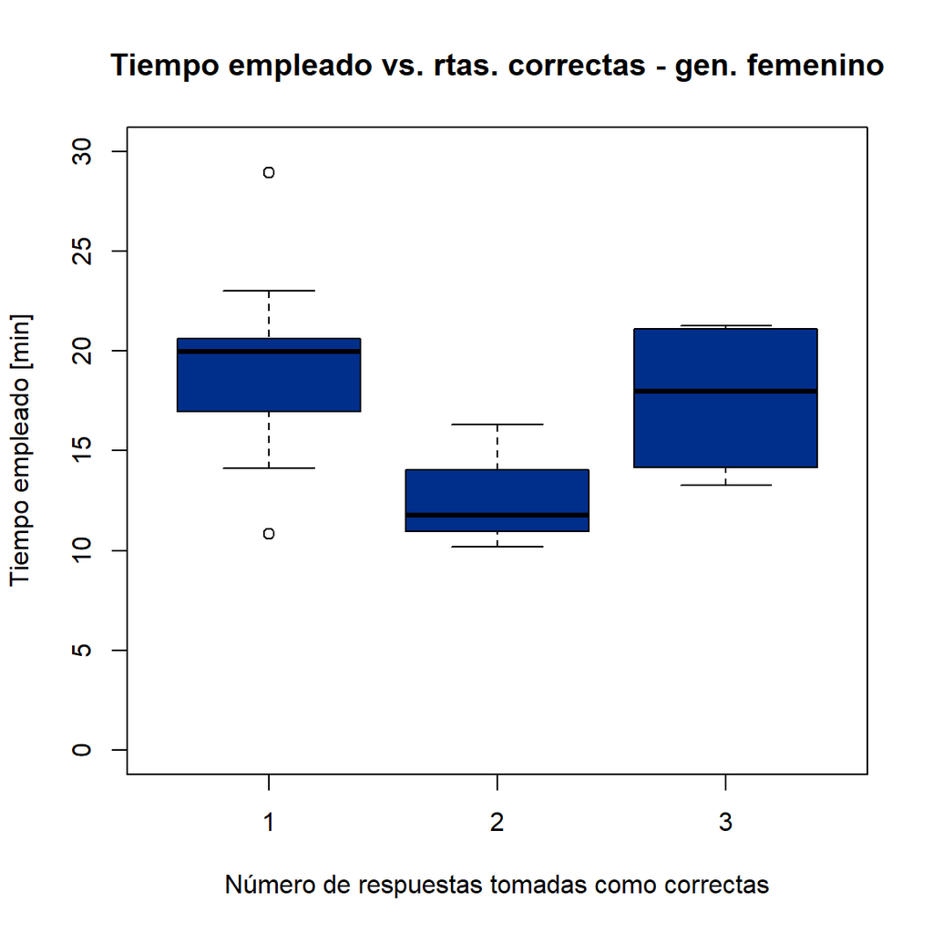

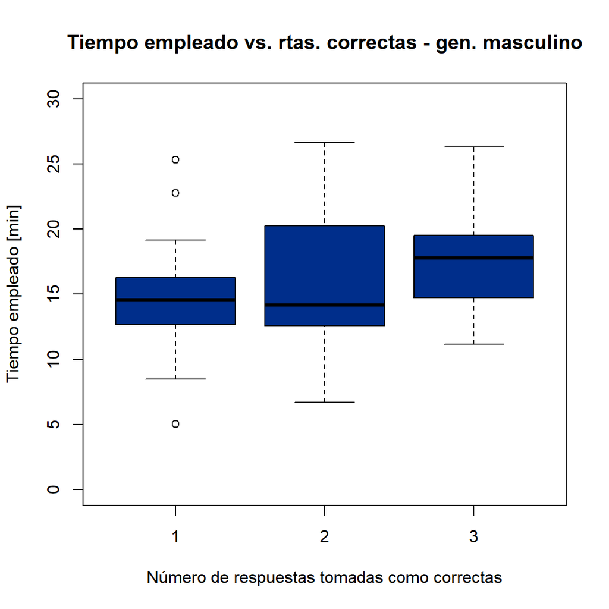

#### Análisis

Con ayuda de los boxplots, se puede establacer primero para cada género lo siguiente: en el caso de las mujeres, salta a la vista que hay evidencia para decir que las mujeres que solo obtuvieron una respuesta correcta se demoraron en promedio más tiempo que las que consiguieron dos respuestas correctas; además, no se puede decir que hayan diferencias en el tiempo promedio usado para resolver la encuesta en los otros casos, como en el caso de una y tres respuestas correctas (si bien se observa que la mediana para el caso de una respuesta correcta es mayor que en el caso de tres respuestas correctas). Por otro lado, en el caso de los hombres, se tiene que no se puede decir que el tiempo en promedio usado por los estudiantes de EDAED de este género haya sido diferente en función del número de respuestas correctas en las preguntas de álgebra, aunque se puede destacar que la mediana de tiempo más alto se haya en el caso de los hombres que obtuvieron tres respuestas correctas.

## Conclusiones generales

### Segunda conclusión: sobre el proceso estadístico.

El uso de herramientas digitales, y en particular de RStudio para este caso, se hace fundamental para realizar análisis estadístico de manera sagaz, oportuna y precisa, en el sentido que facilita realizar una gran diversidad de procesos de manera expedita, ahorrándole tiempo al analista y que puede ser empleado para realizar más análisis estadísticos con los cuales pueda obtenerse mayor información a partir del experimento realizado, en este caso una encuesta.

### Tercera conclusión: sobre el proceso estadístico.

Es evidente que el proceso exploratorio y descriptivo en un análisis estadístico es fundamental, en el sentido que este permite obtener información inicial como datos que no tienen sentido en el marco de alguna variable, para lo cual se puede proceder a realizar diversos procesos de imputación, o realizar filtrados en la base de datos que acerquen al investigador a información útil e interesante que puedan esconder los datos obtenidos a través del experimento. Con esto, se pueden plantear preguntas que orienten mejor un proceso de investigación para así poder pasar a otras fases como los de estimación puntual, análisis inferenciales y de regresión, entre otros.

### Cuarta conclusión: de la encuesta

En general, se observó que el estrato no es un factor influyente en lo que concierne a tener un mejor PAPA en la universidad, lo cual puede estar dando cuenta de que la universidad se encarga, con éxito, de hacer una adecuada nivelación para todos los estudiantes, haciendo que factores exógenos como el estrato sean irrelevantes en cuanto al éxito académico, o bien, sucede que los estudiantes que vienen de zonas con calidad educativa deficiente y que a lo mejor carecen de la preparación académica necesaria para poder afrontar la universidad, son expulsados rápidamente por un bajo rendimiento académico. También puede estar sucediendo que el sistema de Bienestar Universitario es exitoso en cuanto a la garantía de condiciones de subsistencia, bienestar y promoción de actividades y programas orientados a la mejoría de los estudiantes, facilitando su instancia en la universidad.

## Recomendaciones

### Primera recomendación

De acuerdo a la configuración del RStudio, la encuesta no se leía en la codificación correcta, por lo que se distorsionaban ciertos caracteres especiales, como por ejemplo las tildes. Para solucionar esto, se especificó en la función que leía la encuesta que la codificación del archivo csv fuera UTF-8. Por lo tanto, se recomienda tener mucho cuidado a la hora de trabajar encuestas que incluyen caracteres de una codificación específica, para no incurrir en errores a la hora de la depuración y el análisis.

### Segunda recomendación

Para esta encuesta se tomó como el tiempo usado aquel que había entre la hora en que la encuesta fue abierta y el tiempo de entrega. Sin embargo, esto puede presentar una distorsión del tiempo real empleado para resolver esta encuesta, pues no necesariamente se cumple que los estudiantes del curso abrirían la encuesta justo en el momento en que esta fue liberada (de esto hecho se podría etiquetar como simple ya que, en el mejor de los casos, habría una diferencia de algunos milisegundos, ¡y eso con el mejor internet de Colombia!).

En ese sentido, se podría apelar a una herramienta que tienen muchos sistemas de encuestas virtuales que, además de tomar la hora de entrega, registra la hora de inicio de la encuesta, y una vez con esto se pueden realizar las transformaciones adecuadas en un software como R con el objetivo de conseguir el tiempo de solución real.

## Bibliografía

[1] U. Centro de Investigación y Desarrollo de Software CIDS, “Página del Grupo de Admisiones, Registro y Control Académico de la Universidad del Magdalena”, Admisiones.unimagdalena.edu.co, 2021. [En línea]. Disponible en: https://admisiones.unimagdalena.edu.co/inscripcionPRE/conversionICFES.jsp?rnd425615. [Accedido el]: 15- Apr- 2021].